```r
library(dplyr)
library(ggplot2)
infn = "../data/human.csv"
metadata = read.table(infn, sep=",", header=TRUE)
metadata$condition = ifelse(grepl("Healthy", metadata$What), "HC",
                     ifelse(grepl("NASH", metadata$What), "OSA",
                     ifelse(grepl("Steat", metadata$What), "SS", "NAFLD")))
metadata$condition = as.factor(metadata$condition)
metadata$spiked = ifelse(grepl("Spike", metadata$Spike.In), "spike", "nospike")
metadata$column = ifelse(grepl("ymo", metadata$Column), "zymo",
                  ifelse(grepl("None", metadata$Column), "none", "other"))
metadata$id = paste(metadata$Full.Sample.Name, metadata$column, metadata$spiked, metadata$condition, sep="_")
```

```r
library(NanoStringQCPro)
rccFiles = paste("../data/rcc/", metadata[,2], sep="")
eset = newRccSet(rccFiles=rccFiles)
```

```
## Reading RCC files...
```

```
## checkRccSet() messages:
##   Optional featureData cols not found: BarCode, ProbeID, TargetSeq, Species, Comments
##   The following panel housekeeping genes were found: B2M|0, GAPDH|0, RPL19|0, ACTB|0, RPLP0|0
```

```r
colnames(eset) = metadata$id
```

## Scale miRNA with known crosstalk

A small set of miRNA have known inflated values; Nanostring has a heuristic to correct for the inflation via the formula using some supplied constants. Here we implement that fix to correct the expression of those miRNA.

```r
correct_miRNA = function(eset) {
  require(dplyr)
  fdat = fData(eset)
  fdat = fdat %>%
    tidyr::separate(GeneName, c("Name", "scalefactor"), sep='\\|',
                    fill="right", remove=FALSE) %>%
    dplyr::mutate(scalefactor=ifelse(is.na(scalefactor), 0, scalefactor))
  sf = as.numeric(fdat$scalefactor)
  posa = as.numeric(exprs(eset)["Positive_POS_A_ERCC_00117.1",])
  scales = t(replicate(length(sf), posa))
  scales = scales * sf
  scaled = exprs(eset) - scales
  scaled[scaled<0] = 0
  return(round(scaled))
}

plot_corrected_miRNA = function(scaled, eset) {
  require(reshape)
  require(ggplot2)
  counts = exprs(eset)
  rownames(counts) = rownames(scaled)
  is_scaled = rowSums(abs(counts - scaled)) > 0
  counts = melt(as.matrix(counts[is_scaled,]))
  colnames(counts) = c("gene", "sample", "value")
  counts$scaled = "no"
  scaled = melt(as.matrix(scaled[is_scaled,]))
  colnames(scaled) = c("gene", "sample", "value")
  scaled$scaled = "yes"
  all = rbind(counts, scaled)
  library(cowplot)
  ggplot(all, aes(sample, value, color=scaled)) + facet_wrap(~gene) +
    geom_point(size=0.5) +
    theme(axis.title.x=element_blank(),
          axis.text.x=element_blank(),
          axis.ticks.x=element_blank(),
          strip.text.x=element_text(size=8)) +
    guides(colour = guide_legend(override.aes = list(size=6))) + ylab("") +
    ggtitle("miRNA hybridization crosstalk correction")
  }
```

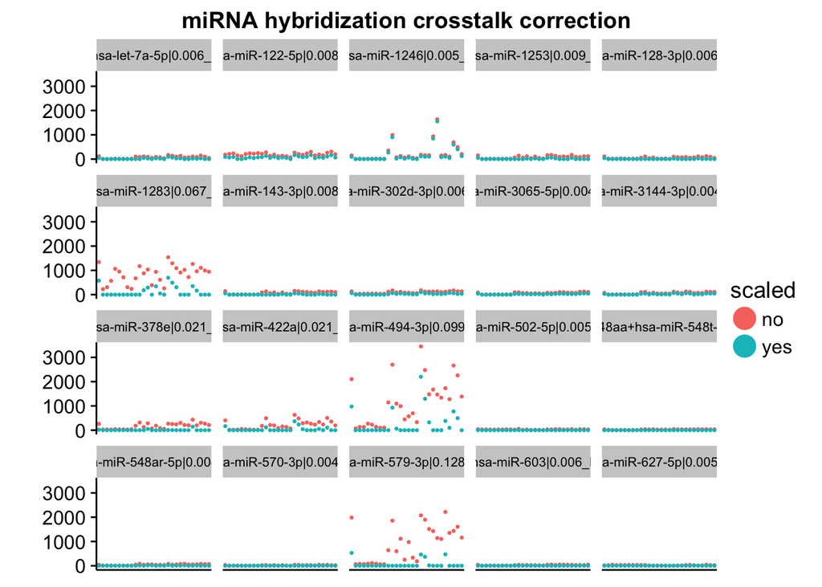

```r
scaled = correct_miRNA(eset)
plot_corrected_miRNA(scaled, eset)
```

```r
counts = as.data.frame(scaled)
colnames(counts) = metadata$id
```

## Imaging QC

This percentage should be super high, close to 100%. If there isn’t that usually means the cartridge needs to be rescanned. If it is < 3 weeks from the scan, rescanning should be okay. Nanostring folks call < 75% a failure. These all look fine.

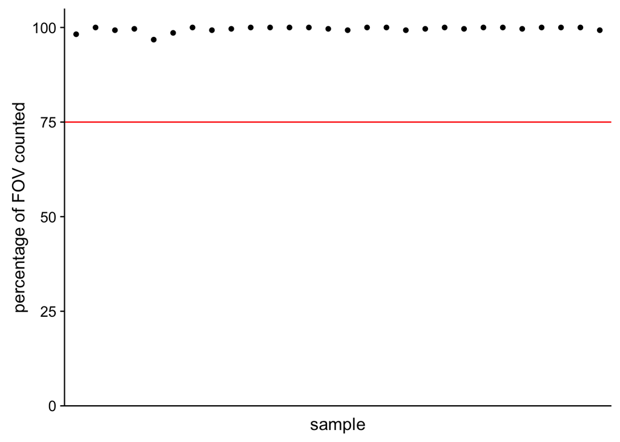

```r
library(cowplot)
pdat = pData(eset) %>%
  tibble::rownames_to_column() %>%
  left_join(metadata, by=c("rowname"="id"))
pdat$pcounted = pdat$FovCounted/pdat$FovCount * 100
ggplot(pdat, aes(rowname, pcounted)) + geom_point() +
    theme(axis.text.x=element_blank(),
          axis.ticks.x=element_blank(),
          strip.text.x=element_text(size=8)) +
  scale_y_continuous(expand = c(0,0)) +
  expand_limits(y = c(0,1.05 * max(pdat$pcounted))) +
  ylab("percentage of FOV counted") + xlab("sample") +
  geom_hline(yintercept=75, color="red")
```

## Binding density

Binding density looks ok.

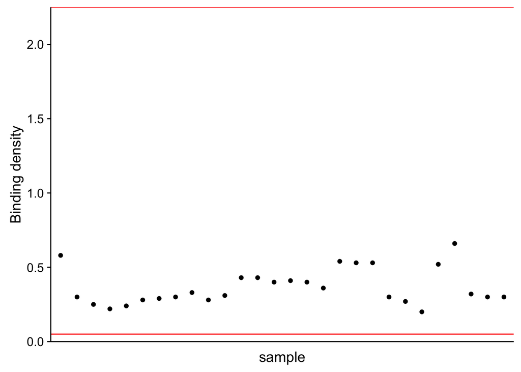

```r
ggplot(pdat, aes(rowname, BindingDensity)) + geom_point() +
    theme(axis.text.x=element_blank(),
          axis.ticks.x=element_blank(),
          strip.text.x=element_text(size=8)) +
  scale_y_continuous(expand = c(0,0)) +
  expand_limits(y = c(0,1.05 * max(pdat$BindingDensity))) +
  ylab("Binding density") + xlab("sample") +
  geom_hline(yintercept=0.05, color="red") +
  geom_hline(yintercept=2.25, color="red")
```

## Total counts vs miRNA detected

Here I plotted the total counts vs the number of miRNA detected, where detected is it has counts > 30. There is a pretty big spread among the samples in terms of the miRNA detected. The Zymo columns seem to all have a low number of miRNA detected.

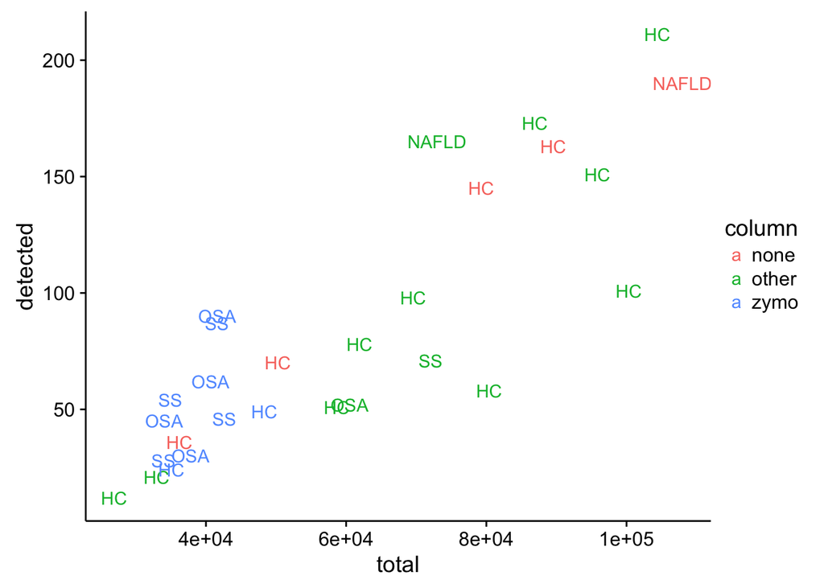

```r
endocounts = counts[grepl("Endo", rownames(counts)),]
cdf = data.frame(total=colSums(counts), detected=colSums(counts > 30))
rownames(cdf) = colnames(counts)
cdf$id = rownames(cdf)
cdf = cdf %>% left_join(metadata, by="id")
ggplot(cdf, aes(total, detected, color=column, label=condition)) +
  geom_text()
```

```r
library(ggplot2)
library(dplyr)
library(cowplot)
is_positive = function(column) {
  return(grepl("Pos", column))
}
is_negative = function(column) {
  return(grepl("Neg", column))
}
is_spikein = function(column) {
  return(grepl("Spike", column))
}
is_ligation = function(column) {
  return(grepl("Ligati", column))
}
is_housekeeping = function(column) {
  return(grepl("Housekee", column))
}
is_prior = function(column) {
  return(grepl("miR-159", column) | grepl("miR-248", column) |
         grepl("miR-254", column))
}

extract_pred = function(counts, predicate) {
  toplot = counts[predicate(rownames(counts)),] %>%
    tibble::rownames_to_column() %>%
    tidyr::gather("sample", "count", -rowname)
  colnames(toplot) = c("spot", "sample", "count")
  toplot = toplot %>% left_join(metadata, by=c("sample"="id"))
  return(toplot)
}
spotbarplot = function(toplot) {
  ggplot(toplot,
        aes(sample, count)) + geom_bar(stat='identity') +
    facet_wrap(~spot) +
    theme(axis.text.x = element_blank(),
          text = element_text(size=8))
}
spotboxplot = function(toplot) {
  ggplot(toplot,
        aes(linehypo, count)) + geom_boxplot() +
    facet_wrap(~spot) +
    theme(axis.text.x = element_text(angle = 90, hjust = 1))
}
```

## Positive controls

Below we look at the R^2 correlation between the expected positive control concentrations and the observed concentrations for each sample.

A set of samples have a lower correlation than the other samples.

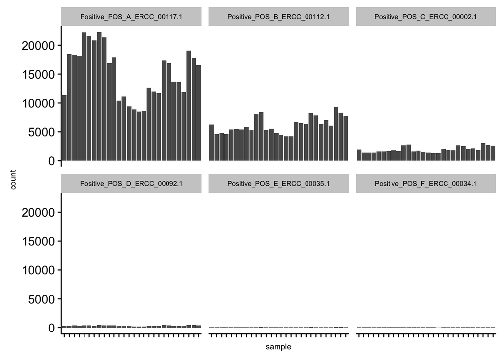

```r
spotbarplot(extract_pred(counts, is_positive))
```

```r
pcdf = data.frame(concentration=log2(c(128, 32, 8, 2, 0.5, 0.125)),
                  GeneName=paste("POS", c("A", "B", "C", "D", "E", "F"), sep="_"))
pccounts = subset(exprs(eset), grepl("Positive_POS", rownames(exprs(eset))))
pccounts = pccounts[sort(rownames(pccounts)),]
rownames(pccounts) = pcdf$GeneName
corsamples = data.frame(correlation=apply(pccounts, 2,
                                          function(x) cor(x, pcdf$concentration)),
                        sample=colnames(pccounts)) %>%
  left_join(metadata, by=c("sample"="id"))
```

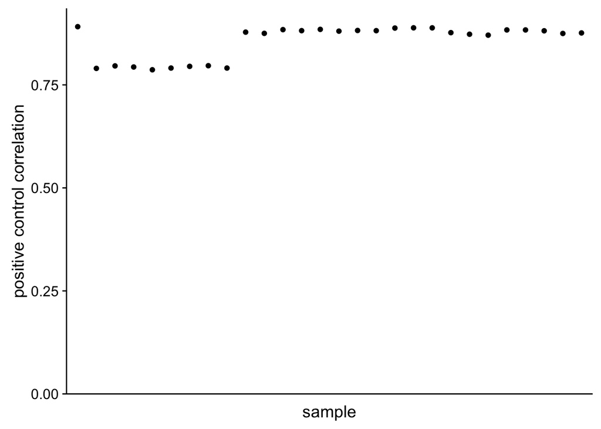

```r
ggplot(corsamples, aes(sample, correlation)) + geom_point() +
    theme(axis.text.x=element_blank(),
          axis.ticks.x=element_blank(),
          strip.text.x=element_text(size=8)) +
  scale_y_continuous(expand = c(0,0)) +
  expand_limits(y = c(0,1.05 * max(corsamples$correlation))) +
  ylab("positive control correlation") +
  xlab("sample")
```

Those are all Zymo columns. 8 of the 10 Zymo columns have this problem. If it looks like they have other issues, it might be best to just exclude them.

```r
subset(corsamples, correlation < 0.80)$sample
```

```
## [1] "179ON_zymo_spike_OSA" "258ON_zymo_spike_OSA" "035ON_zymo_spike_OSA"
## [4] "448ON_zymo_spike_OSA" "048SS_zymo_spike_SS"  "037ss_zymo_spike_SS"
## [7] "163SS_zymo_spike_SS"  "114SS_zymo_spike_SS"
```

## Negative controls

We can see some samples have a higher negative control count than the other samples.

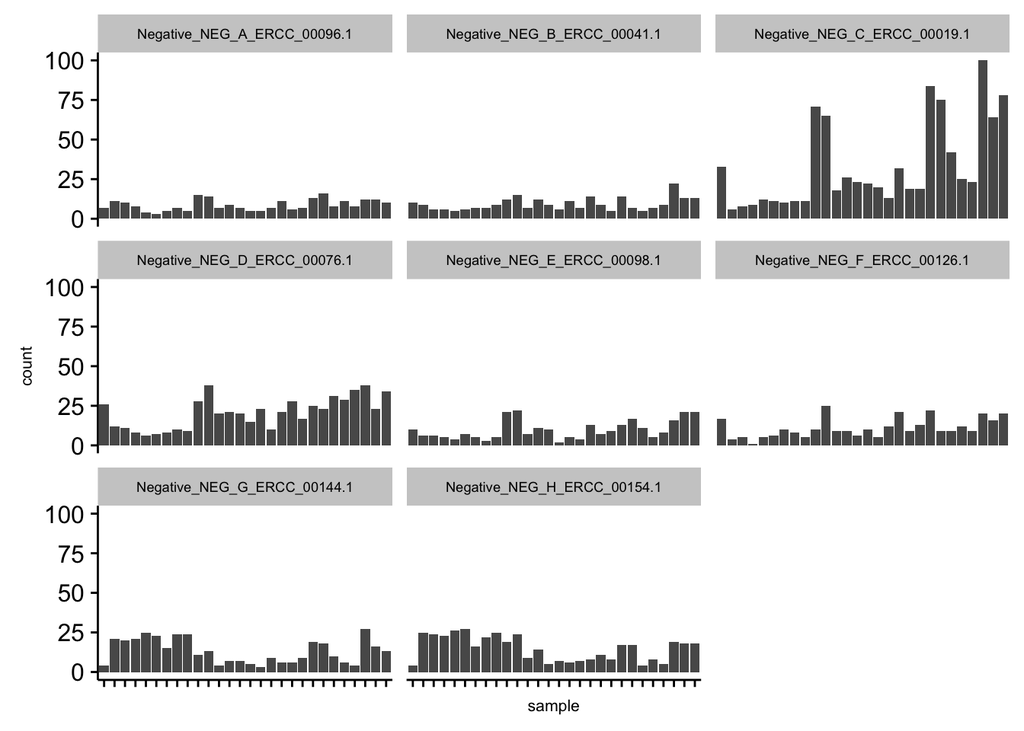

```r
spotbarplot(extract_pred(counts, is_negative))
```

```r
knitr::kable(subset(extract_pred(counts, is_negative), count > 50))
```

|  | spot | sample | count | File.Name | FULL.RCC.File.Name | Pure.Sample.Name | Full.Sample.Name | Clinical.Category | What | Column | Spike.In | Notes | Date.Shipped | RCC.File.Date | condition | spiked | column |
| --- | --- | --- | --- | --- | --- | --- | --- | --- | --- | --- | --- | --- | --- | --- | --- | --- | --- |
| NA |  |  |  |  |  |  |  |  |  |  |  |  |  |  |  |  |  |
| 17 | Negative_NEG_C_ERCC_00019.1 | T1N_none_nospike_HC | 75 | ..03 | 20150421_PHS 1_01_03.RCC | T1 | T1N | Healthy Control | Healthy control 1 -vial 1 | None | None | optimization | 4.6.15 | 4.21.2015 | HC | nospike | none |
| 25 | Negative_NEG_C_ERCC_00019.1 | T1A_other_nospike_HC | 84 | ..04 | 20150421_PHS 1_01_04.RCC | T1 | T1A | Healthy Control | Healthy control 1 -vial 1 | Amicon | None | optimization | 4.6.15 | 4.21.2015 | HC | nospike | other |
| NA |  |  |  |  |  |  |  |  |  |  |  |  |  |  |  |  |  |
| NA |  |  |  |  |  |  |  |  |  |  |  |  |  |  |  |  |  |
| NA |  |  |  |  |  |  |  |  |  |  |  |  |  |  |  |  |  |
| NA |  |  |  |  |  |  |  |  |  |  |  |  |  |  |  |  |  |

## Noise floor cutoff

We’ll normalize the libraries and look at the negative control expression and then come up with a cutoff that is above the noise floor for the libraries. It looks like 30 is a reasonable noise floor to use.

```r
drop_unusable = function(counts) {
  drop = is_spikein(rownames(counts))
  drop = drop | is_positive(rownames(counts))
  drop = drop | is_housekeeping(rownames(counts))
  drop = drop | is_ligation(rownames(counts))
  keep = counts[!drop,]
  keep = keep[, !grepl("Blank", colnames(keep))]
  return(keep)
}
library(DESeq2)
dds = DESeqDataSetFromMatrix(drop_unusable(counts), colData=metadata,
                             design=~spiked+column+condition)
```

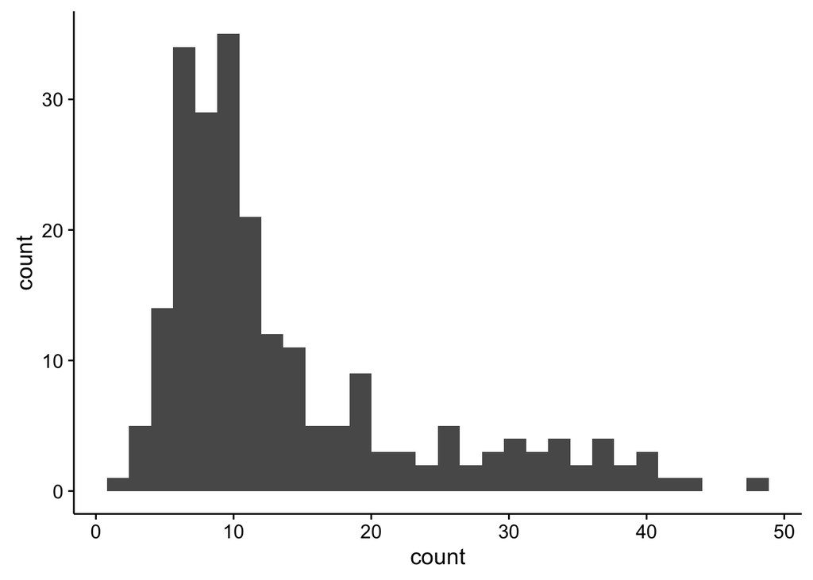

```r
dds = estimateSizeFactors(dds)
ncounts = data.frame(counts(dds, normalized=TRUE))
ggplot(extract_pred(ncounts, is_negative), aes(count)) + geom_histogram()
```

```r
nfloor = 30
```

## SpikeIn

We don’t have many spike in sets in this sample either, so we can’t really use the spike ins.

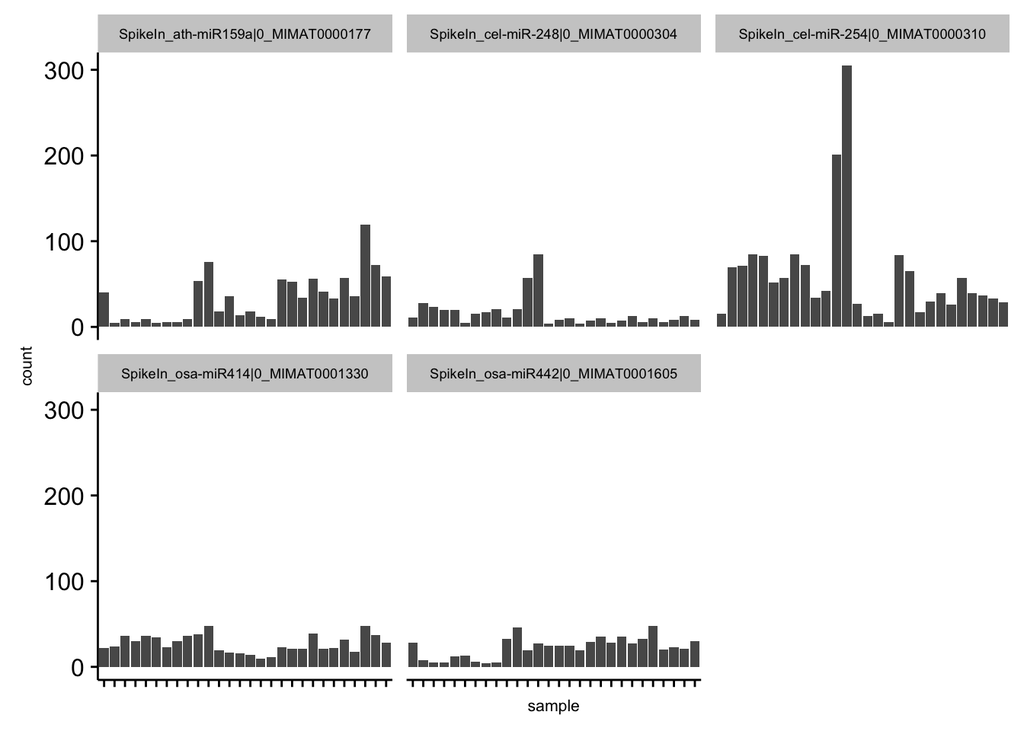

```r
spotbarplot(extract_pred(counts, is_spikein))
```

```r
knitr::kable(subset(extract_pred(counts, is_spikein), count > 100))
```

|  | spot | sample | count | File.Name | FULL.RCC.File.Name | Pure.Sample.Name | Full.Sample.Name | Clinical.Category | What | Column | Spike.In | Notes | Date.Shipped | RCC.File.Date | condition | spiked | column |
| --- | --- | --- | --- | --- | --- | --- | --- | --- | --- | --- | --- | --- | --- | --- | --- | --- | --- |
| NA |  |  |  |  |  |  |  |  |  |  |  |  |  |  |  |  |  |
| 113 | SpikeIn_cel-miR-254\|0_MIMAT0000310 | A1_none_spike_HC | 305 | ..07 | 20160114_ES011416miRNAV3a_Stock sampleA1_07.RCC | A1 | A1 | Healthy Control | Healthy control 4 - vial 1 | None | +Spike In | optimization | 1.4.16 | 1.14.16 | HC | spike | none |
| 118 | SpikeIn_cel-miR-254\|0_MIMAT0000310 | A10_zymo_spike_HC | 201 | ..08 | 20160114_ES011416miRNAV3a_Stock sampleA2O_08.RCC | A10 | A10 | Healthy Control | Healthy control 4 -vial 10 | Zymo | +Spike In | optimization | 1.4.16 | 1.14.16 | HC | spike | zymo |

## Ligation

Some of the ligation controls are drastically different between samples.

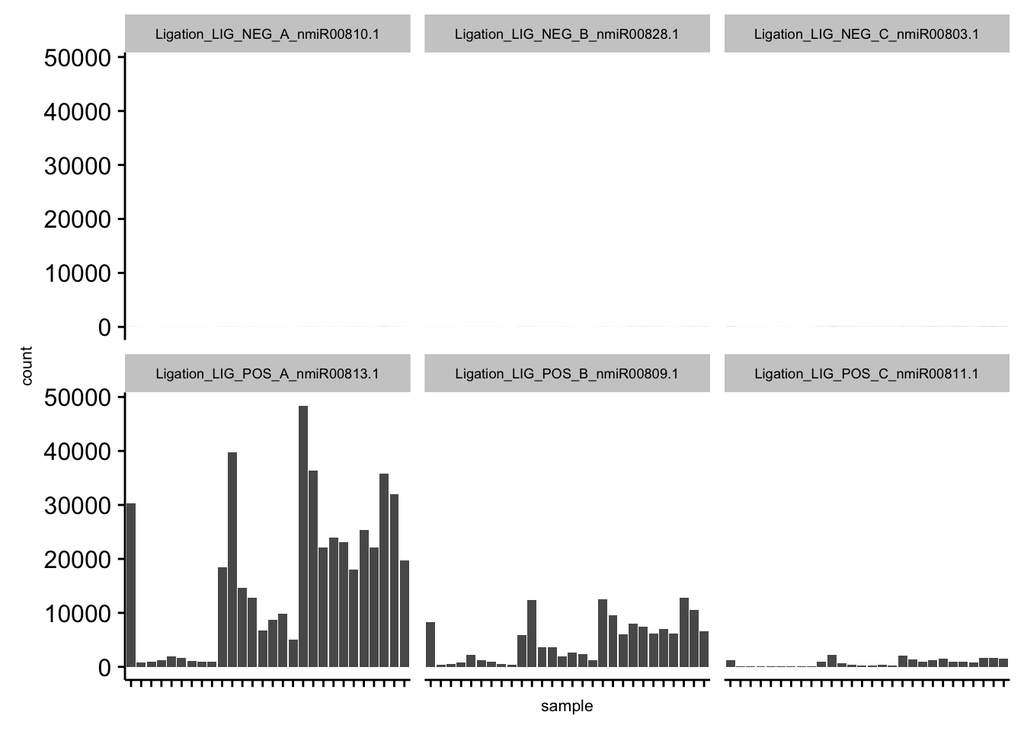

```r
spotbarplot(extract_pred(counts, is_ligation))
```

## Ligation control R^2

Here we look at R^2 for the ligation controls as well. It looks like one sample looks bad. It is a Zymo column.

```r
pcdf = data.frame(concentration=log2(c(128, 32, 8)),
                  GeneName=paste("POS_", c("A", "B", "C"), sep="_"))
pccounts = subset(exprs(eset), grepl("Ligation_LIG_POS", rownames(exprs(eset))))
pccounts = pccounts[sort(rownames(pccounts)),]
rownames(pccounts) = pcdf$GeneName
corsamples = data.frame(correlation=apply(pccounts, 2,
                                          function(x) cor(x, pcdf$concentration)),
                        sample=colnames(pccounts)) %>%
  left_join(metadata, by=c("sample"="id"))
```

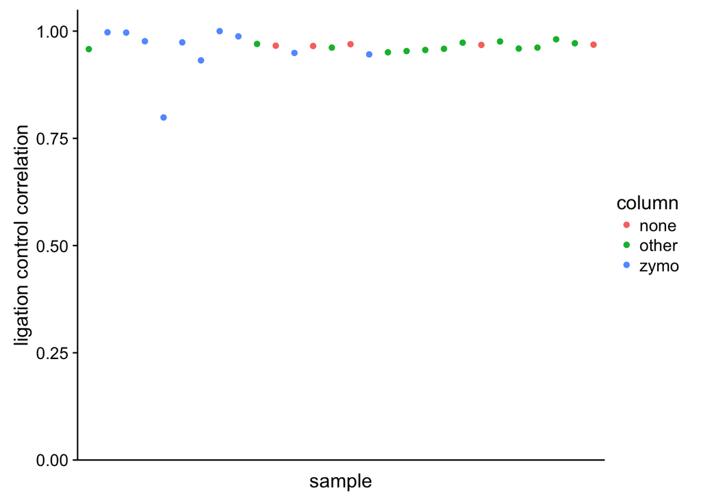

```r
ggplot(corsamples, aes(sample, correlation, color=column)) + geom_point() +
    theme(axis.text.x=element_blank(),
          axis.ticks.x=element_blank(),
          strip.text.x=element_text(size=8)) +
  scale_y_continuous(expand = c(0,0)) +
  expand_limits(y = c(0,1.05 * max(corsamples$correlation))) +
  ylab("ligation control correlation") +
  xlab("sample")
```

## Ligation efficiency

Here we calculated ligation efficiency for the samples. This is the log of LIG_POS_A(i) / mean(LIG_POS_A) for each sample i. It doesn’t matter which direction this is in, it will get corrected for in the model. Again we can see most of the Zymo columns are outliers in this.

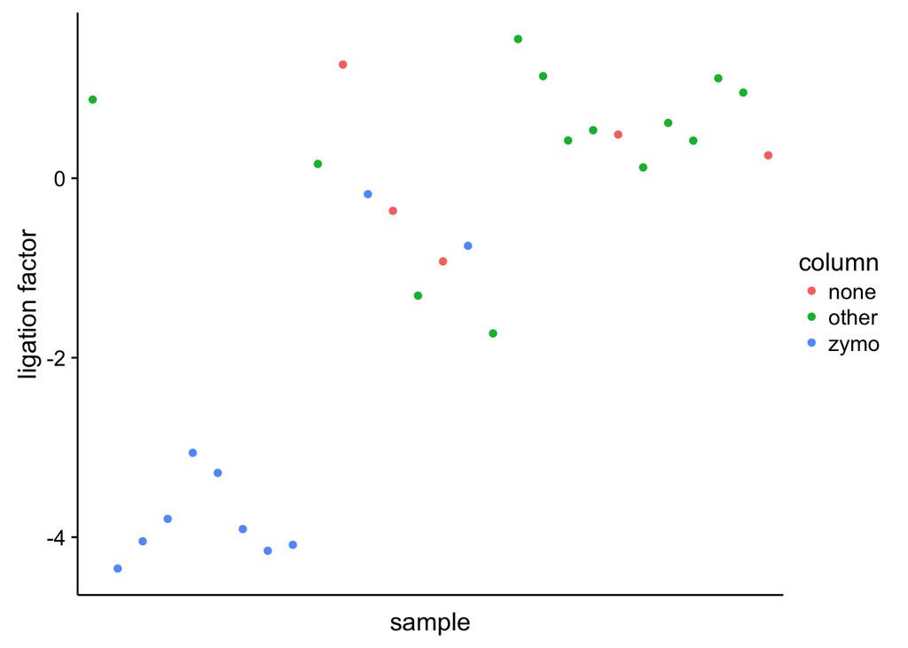

```r
lig_posa = as.numeric(counts[grepl("Ligation_LIG_POS_A", rownames(counts)),])
metadata$lignorm = log2(lig_posa / mean(lig_posa))
ggplot(metadata, aes(id, lignorm, color=column)) + geom_point() +
    theme(axis.text.x=element_blank(),
          axis.ticks.x=element_blank(),
          strip.text.x=element_text(size=8)) +
  ylab("ligation factor") +
  xlab("sample")
```

## Housekeeping

Some housekeeping genes are expressed more highly in some samples. Not sure what we are supposed to do with this information, if there are any suggestions we could easily implement it.

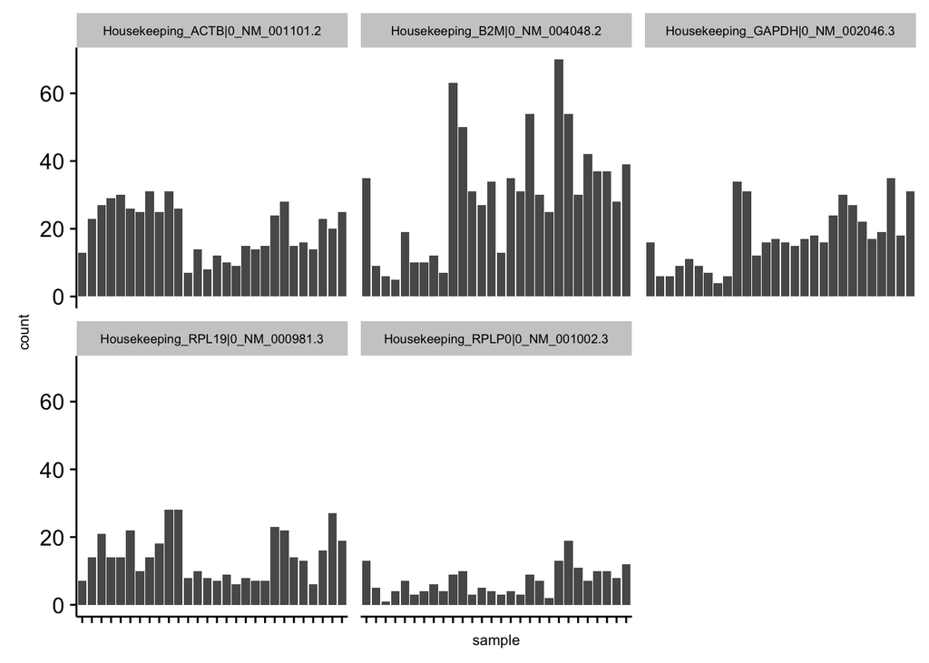

```r
spotbarplot(extract_pred(counts, is_housekeeping))
```

## Drop control miRNA

```r
drop_unusable = function(counts) {
  drop = is_spikein(rownames(counts))
  drop = drop | is_positive(rownames(counts))
  drop = drop | is_housekeeping(rownames(counts))
  drop = drop | is_ligation(rownames(counts))
  keep = counts[!drop,]
  keep = keep[, !grepl("Blank", colnames(keep))]
  return(keep)}
counts = drop_unusable(counts)
metadata = subset(metadata, id %in% colnames(counts))
```

## Does normalization for ligation effiency buy us anything?

Yes, it looks like even after normalization, if we fit a model with just the ligation efficiency that there are miRNA affected. So we should correct for that. Here you can see only a subset of the miRNA are affected; if we do it like this instead of just scaling the counts, we can correct for the specific miRNA that have counts that are correlated with the ligation efficiency.

```r
full = ~spiked+column+lignorm+condition
reduced = ~spiked+column+condition
dds = DESeqDataSetFromMatrix(counts, colData=metadata,
                             design=full)
dds = DESeq(dds, full=full, reduced=reduced, test="LRT")
```

```
## -- note: fitType='parametric', but the dispersion trend was not well captured by the
##    function: y = a/x + b, and a local regression fit was automatically substituted.
##    specify fitType='local' or 'mean' to avoid this message next time.
```

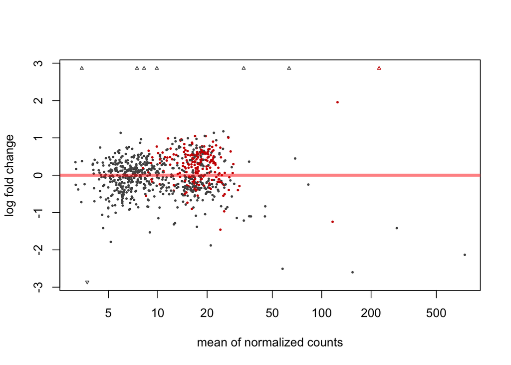

```r
res = results(dds)
plotMA(res)
```

```r
res = data.frame(res) %>% tibble::rownames_to_column() %>%
  arrange(padj) %>% filter(padj < 0.05)
knitr::kable(subset(res, padj < 0.05))
```

| rowname | baseMean | log2FoldChange | lfcSE | stat | pvalue | padj |
| --- | --- | --- | --- | --- | --- | --- |
| Endogenous1_hsa-miR-3144-3p\|0.004_MIMAT0015015 | 16.154394 | -0.9025371 | 0.7035110 | 24.623316 | 0.0000007 | 0.0001413 |
| Endogenous1_hsa-miR-520f-3p\|0_MIMAT0002830 | 22.485535 | 0.2807425 | 0.3116032 | 25.036669 | 0.0000006 | 0.0001413 |
| Endogenous1_hsa-miR-3065-5p\|0.004_MIMAT0015066 | 15.168313 | -0.7366578 | 0.7019716 | 24.325572 | 0.0000008 | 0.0001413 |
| Endogenous1_hsa-miR-1246\|0.005_MIMAT0005898 | 116.492298 | -1.2476974 | 1.0380849 | 20.863565 | 0.0000049 | 0.0005558 |
| Endogenous1_hsa-miR-128-1-5p\|0_MIMAT0026477 | 12.508796 | 0.5570638 | 0.3300627 | 20.689024 | 0.0000054 | 0.0005558 |
| Endogenous1_hsa-miR-455-5p\|0_MIMAT0003150 | 14.969105 | 0.0843940 | 0.3722625 | 20.364295 | 0.0000064 | 0.0005558 |
| Endogenous1_hsa-miR-5010-3p\|0_MIMAT0021044 | 17.040506 | 0.0619138 | 0.4116098 | 19.907844 | 0.0000081 | 0.0006049 |
| Endogenous1_hsa-miR-302d-3p\|0.006_MIMAT0000718 | 25.431722 | -0.9679320 | 0.9944600 | 19.138108 | 0.0000122 | 0.0007919 |
| Endogenous1_hsa-miR-494-3p\|0.099_MIMAT0002816 | 223.791055 | 3.6464008 | 2.3876034 | 17.927622 | 0.0000229 | 0.0013284 |
| Endogenous1_hsa-miR-369-3p\|0_MIMAT0000721 | 21.623242 | 0.4177050 | 0.3211391 | 16.701565 | 0.0000437 | 0.0022791 |
| Endogenous1_hsa-miR-652-5p\|0_MIMAT0022709 | 9.151777 | -0.1159365 | 0.4449504 | 15.874251 | 0.0000677 | 0.0032062 |
| Endogenous1_hsa-miR-4536-3p\|0_MIMAT0020959 | 16.773122 | 0.3667219 | 0.3519397 | 15.645154 | 0.0000764 | 0.0033174 |
| Endogenous1_hsa-miR-301a-3p\|0_MIMAT0000688 | 17.751937 | 0.1109434 | 0.3778992 | 14.537738 | 0.0001374 | 0.0055058 |
| Endogenous1_hsa-miR-574-5p\|0_MIMAT0004795 | 28.637916 | 0.0586027 | 0.3650343 | 14.113693 | 0.0001721 | 0.0064041 |
| Endogenous1_hsa-miR-137\|0_MIMAT0000429 | 18.632380 | 0.7747747 | 0.3287266 | 13.661072 | 0.0002189 | 0.0076047 |
| Endogenous1_hsa-miR-4485-3p\|0_MIMAT0019019 | 16.053723 | 0.2895543 | 0.3477983 | 13.498416 | 0.0002388 | 0.0077748 |
| Endogenous1_hsa-miR-526b-5p\|0_MIMAT0002835 | 18.250371 | 0.5267871 | 0.3932647 | 12.734332 | 0.0003590 | 0.0110024 |
| Endogenous1_hsa-miR-449b-5p\|0_MIMAT0003327 | 17.239821 | 0.5103844 | 0.3297778 | 12.597866 | 0.0003862 | 0.0111780 |
| Endogenous1_hsa-miR-532-3p\|0_MIMAT0004780 | 20.808011 | 0.3420041 | 0.3604824 | 12.259381 | 0.0004629 | 0.0121452 |
| Endogenous1_hsa-miR-302a-3p\|0_MIMAT0000684 | 15.481374 | 0.2835056 | 0.4152712 | 12.246119 | 0.0004662 | 0.0121452 |
| Endogenous1_hsa-miR-1228-3p\|0_MIMAT0005583 | 20.384874 | 0.6921693 | 0.3517339 | 12.130477 | 0.0004960 | 0.0123066 |
| Endogenous1_hsa-miR-508-5p\|0_MIMAT0004778 | 15.773746 | 0.4022628 | 0.3453756 | 11.918572 | 0.0005558 | 0.0125894 |
| Endogenous1_hsa-miR-5001-5p\|0_MIMAT0021021 | 17.611257 | 0.4877155 | 0.3718538 | 11.935469 | 0.0005508 | 0.0125894 |
| Negative_NEG_G_ERCC_00144.1 | 14.468579 | 0.6236652 | 0.3667758 | 11.797464 | 0.0005931 | 0.0128755 |
| Endogenous1_hsa-miR-2682-5p\|0_MIMAT0013517 | 21.076116 | -0.3664644 | 0.3835798 | 11.654597 | 0.0006404 | 0.0133468 |
| Endogenous1_hsa-miR-3613-3p\|0_MIMAT0017991 | 17.943783 | 0.3190873 | 0.3342189 | 11.310878 | 0.0007705 | 0.0148686 |
| Endogenous1_hsa-miR-199a-5p\|0_MIMAT0000231 | 20.873884 | 0.2023188 | 0.3238177 | 11.344748 | 0.0007566 | 0.0148686 |
| Endogenous1_hsa-miR-184\|0_MIMAT0000454 | 19.362627 | 0.6128443 | 0.3777975 | 11.105977 | 0.0008605 | 0.0154593 |
| Endogenous1_hsa-miR-6720-3p\|0_MIMAT0025851 | 12.246648 | 0.4267901 | 0.4126011 | 11.139837 | 0.0008449 | 0.0154593 |
| Endogenous1_hsa-miR-525-5p\|0_MIMAT0002838 | 24.296625 | 0.4785322 | 0.3128488 | 10.913644 | 0.0009546 | 0.0165780 |

[output cut: 82 more lines]

## PCA

Here we can see the choice of column is what separates out the samples, it is going to be hard to call differences because the column type is confounded with the sample type for the most part. We only have one observation of non-zymo columns for the OSA and SS samples.

```r
dds = DESeqDataSetFromMatrix(counts, colData=metadata, design=full)
vst = varianceStabilizingTransformation(dds)
```

```
## -- note: fitType='parametric', but the dispersion trend was not well captured by the
##    function: y = a/x + b, and a local regression fit was automatically substituted.
##    specify fitType='local' or 'mean' to avoid this message next time.
```

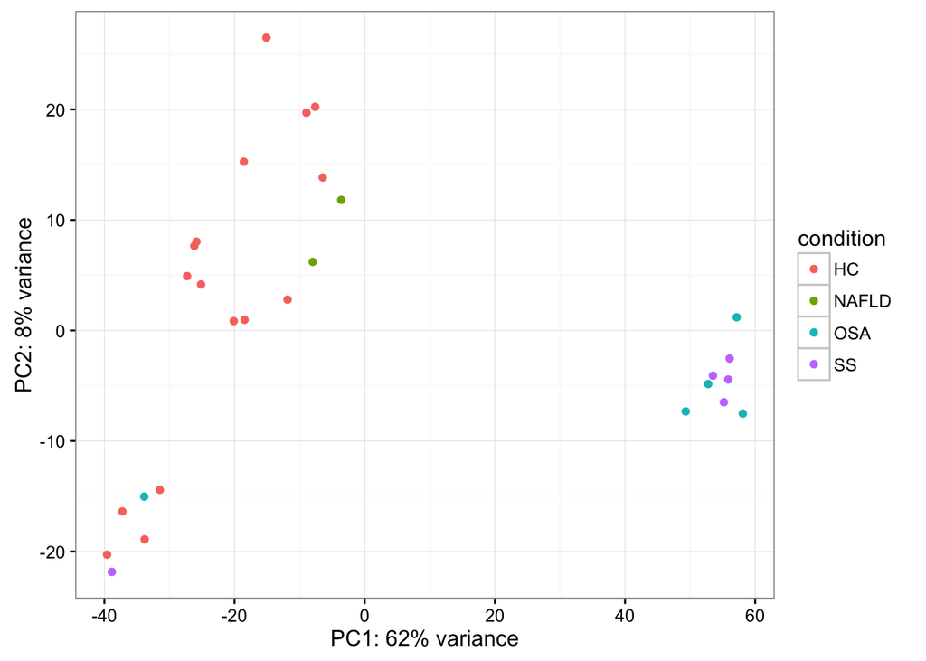

```r
pca_loadings = function(object, ntop=500) {
  rv <- matrixStats::rowVars(assay(object))
  select <- order(rv, decreasing = TRUE)[seq_len(min(ntop,
      length(rv)))]
  pca <- prcomp(t(assay(object)[select, ]))
  percentVar <- pca$sdev^2/sum(pca$sdev^2)
  names(percentVar) = colnames(pca$x)
  pca$percentVar = percentVar
  return(pca)}
pc = pca_loadings(vst)
comps = data.frame(pc$x)
comps$Name = rownames(comps)
library(dplyr)
comps = comps %>% left_join(metadata, by=c("Name"="id"))
pca_plot = function(comps, nc1, nc2, colorby) {
   c1str = paste0("PC", nc1)
   c2str = paste0("PC", nc2)
  ggplot(comps, aes_string(c1str, c2str, color=colorby)) +
    geom_point() + theme_bw() +
    xlab(paste0(c1str, ": ", round(pc$percentVar[nc1] * 100), "% variance")) +
    ylab(paste0(c2str, ": ", round(pc$percentVar[nc2] * 100), "% variance"))
  }
pca_plot(comps, 1, 2, "condition")
```

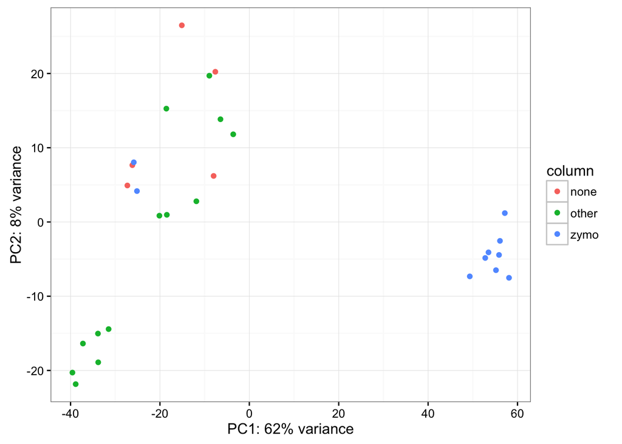

```r
pca_plot(comps, 1, 2, "column")
```

It isn’t clear what is separating out the samples on the lower left.

## Differential expression

```r
write_results = function(res, fname) {
  res = data.frame(res) %>% tibble::rownames_to_column() %>%
    arrange(pvalue)
  write.table(res, file=fname, quote=FALSE, col.names=TRUE,
              row.names=FALSE, sep=",")
}
dds = DESeq(dds, fitType='local')
```

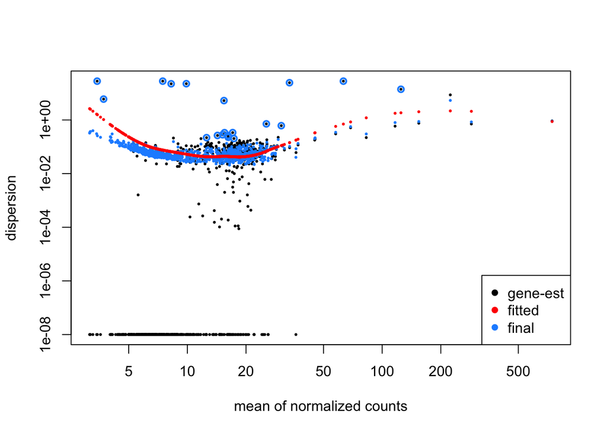

```r
plotDispEsts(dds)
```

## OSA/NASH vs HC

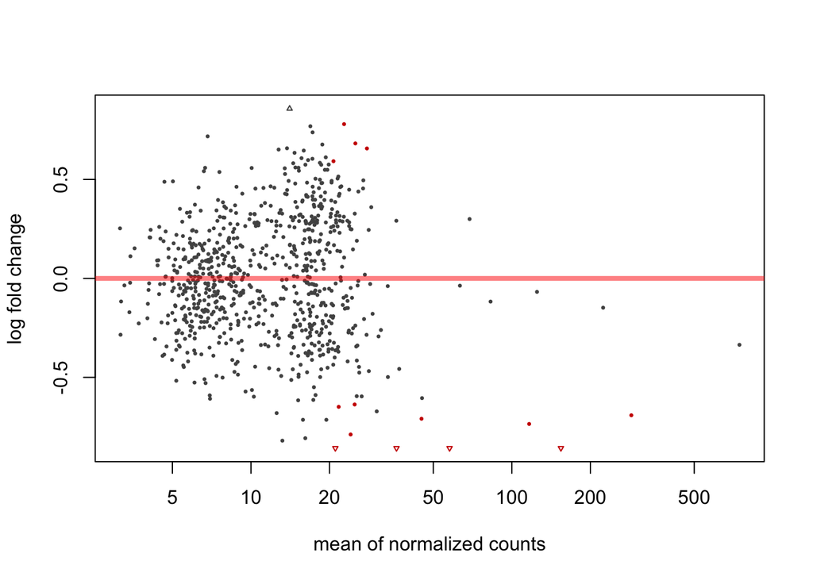

```r
res = results(dds, contrast=c("condition", "OSA", "HC"))
plotMA(res)
```

```r
write_results(res, "OSA-vs-HC.csv")
```

## OSA/NASH vs SS

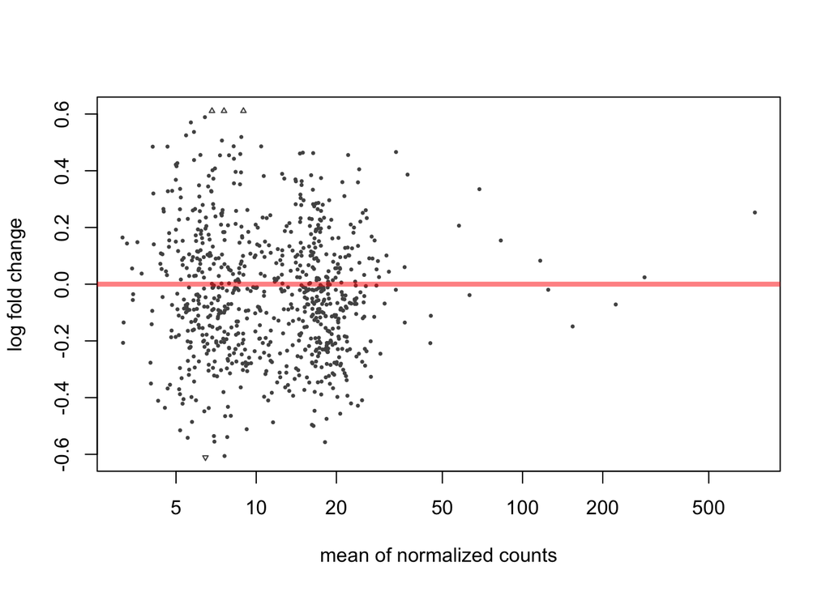

```r
res = results(dds, contrast=c("condition", "OSA", "SS"))
plotMA(res)
```

```r
write_results(res, "OSA-vs-SS.csv")
```

## SS vs HC

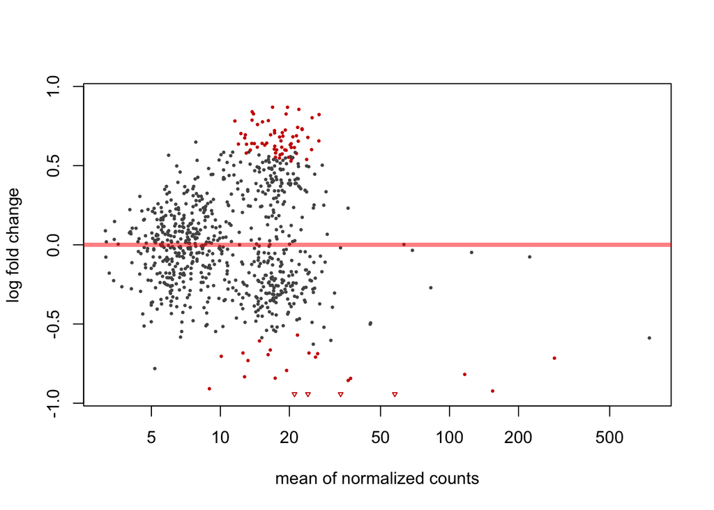

```r
res = results(dds, contrast=c("condition", "SS", "HC"))
plotMA(res)
```

```r
write_results(res, "SS-vs-HC.csv")
```

## Output tables

OSA vs HC

OSA vs SS

SS vs HC